# Core Quants Week 10 classwork solution

Lukas Wallrich

18/02/2021

# Solutions

Below, I show the corrected code as well as brief commentary regarding what was wrong. If anything is unclear, please ask.

For this exercise, we will go back to the `dslabs` package as it offers various datasets we can use here. Note than if you ever overwrite one of these datasets, you can run `rm(gapminder)` - or whatever dataset to use - to remove your copy and get R to go back to the version included in `dslabs`. To get more information about the dataset, call up its help page with the ? operator in the console, e.g., `?brexit_polls`

```r
library(tidyverse)
library(dslabs)
```

# Summarising and mutating data

```r
#Using gapminder, calculate the average life expectancy in Africa
## - fix three mistakes per line

gapminder %>% filter(continent == "Africa") %>%
  summarise(mean(life_expectancy, na.rm = TRUE))
```

```
##   mean(life_expectancy, na.rm = TRUE)
## 1                            54.38155
```

- R never changes data in place - so just filtering gapminder without saving the result will have no influence on future lines. The easiest way here is to combine the two steps into one pipe.
- `==` for comparisons, `=` only for setting arguments in functions and names in `mutate`, `summarise`, `rename` etc.
- Strings (`"Africa"`) always need to be in quotation marks. Variable names should not be (`life_expectancy`), at least within the tidyverse.
- Summary functions should only be used with the pipe inside summarise - remember that the pipe places the left-hand side as the first argument of the right-hand side function, and `mean(gapminder, life_expectancy)` is not correct.
- `mean()` needs to be called with `na.rm = TRUE` when you have missing data

```r
#Calculate the gdp_per_capita for each line in gapminder - fix two mistakes (closely related)
#(if you have modified the dataset above, run rm(gapminder) to get the original dataset from dslabs back)

#Either
gapminder <- gapminder %>% mutate(gdp_per_capita = gdp/population)
#Or
gapminder$gdp_per_capita <- gapminder$gdp/gapminder$population
```

- All dplyr functions return dataframes, so it makes no sense to assign them to individual variables. If you ever want to call variables directly, using the `$`, best stay clear of dplyr functions.

```r
#Calculate the average fertility per continent and the number of rows included in that calculation - three mistakes
gapminder %>% group_by(continent) %>% summarise(mean_fertility = mean(fertility, na.rm = TRUE), n_rows = n())
```

```
## # A tibble: 5 x 3
##   continent mean_fertility n_rows
##   <fct>              <dbl>  <int>
## 1 Africa              5.85   2907
## 2 Americas            3.65   2052
## 3 Asia                4.18   2679
## 4 Europe              1.97   2223
## 5 Oceania             4.35    684
```

- `group_by()` instead of `by()`
- Within `summarise`, use `=` to name the different summary statistics. `<-` should only be used to create stand-alone objects.
- To count the number of rows, ususally after `group_by()`, use `n()`. `count()` counts the number of times each value appears within a specific variable, and thus needs an x argument (and returns a dataframe, so that it cannot be used inside summarise).

```r
#Using olive dataset
#Calculate a new variable that shows the combined share of linoleic and linolenic acid - fix one mistake

olive <- olive %>% mutate(tot_lino = linoleic + linolenic)
```

- `sum()` and other summary functions return one value for the entire dataset - if you use them in mutate, each row will contain the same value. If you can, use basic calculations (i.e. `+`) instead. If you can’t, e.g., for minimum and maximum values, check the rowwise function such as `rowSums()` or `pmin()` or dplyr’s `rowwise()`

# Plotting data

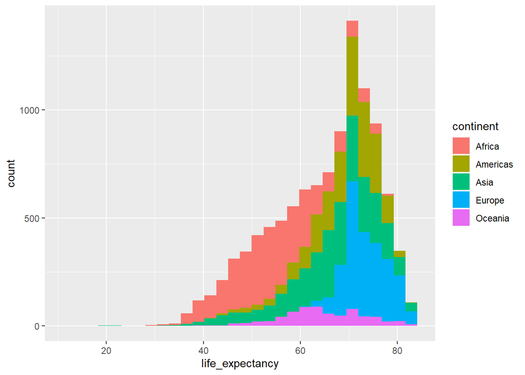

```r
#Create a histogram of life_expectancy in gapminder, with the bars filled in different colours to indicate the continent - four mistakes
ggplot(gapminder, aes(life_expectancy, fill = continent)) + geom_histogram()
```

- Check for missing brackets - the second closing bracket usually needed in ggplot() is one of the most common mistakes.
- Again, pass variable names as bare text, not within "" - this does not throw an error, but just colours everything the same, since “continent” is just one specific word.
- `ggplot2` elements are combined with `+`, not with `%>%`.
- Filling something with a colour is done with `fill =`, while `color =` concerns outlines. (Note that this is not a great visualisation - but fill is very useful in other circumstances.)

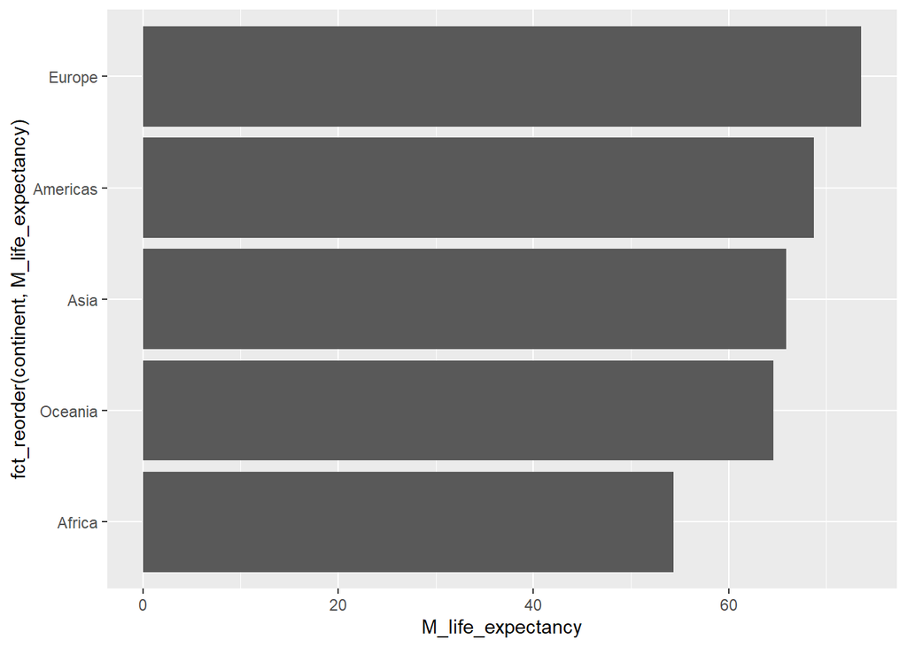

```r
#Show life expectancy per continent in a bar chart sorted from smallest to largest - two mistakes
gapminder %>% group_by(continent) %>% summarise(M_life_expectancy = mean(life_expectancy, na.rm = TRUE)) %>% ggplot(aes(x=fct_reorder(continent, M_life_expectancy), y=M_life_expectancy)) + geom_col() + coord_flip()
```

```r
#Additional task: turn the chart above from vertical into horizontal bars (that is generally a good idea when your labels are not very short)
```

- `summarise()` changes variable names - that then needs to be reflected inside `aes()`.
- `geom_bar()` automatically sets the y-axis to contain a count, which might be helpful if you wanted to show how many rows contain information on each continent. If you want to be able to define your own y-value, you either need to use stat = “identity” as an argument to geom_bar() or, more easily, geom_col() instead.
- To switch x and y-axis, use `coord_flip()`, to order a categorical axis by the values on another variable, use `fct_reorder(variable, by)`. Obviously, that then really calls for new axis labels, but that’s not the focus here.

# Statistical modeling

```r
#Test whether there is a significant relationship between infant_mortality and fertility in Asia - one mistake per line
#Challenge, but not necessary: get this fixed by changing only 1-2 letters per line. For the first, you would first need to load the magrittr package

gapminder %>% filter(continent == "Asia") %>% lm(infant_mortality ~ fertility, .)
```

```
##
## Call:
## lm(formula = infant_mortality ~ fertility, data = .)
##
## Coefficients:
## (Intercept)    fertility
##      -14.98        17.03
```

```r
library(magrittr)
gapminder %>% filter(continent == "Asia") %$% cor.test(infant_mortality, fertility)
```

```
##
##  Pearson's product-moment correlation
##
## data:  infant_mortality and fertility
## t = 45.778, df = 2237, p-value < 2.2e-16
## alternative hypothesis: true correlation is not equal to 0
## 95 percent confidence interval:
##  0.6734498 0.7162623
## sample estimates:
##       cor
## 0.6954728
```

- Neither `cor.test()` nor `lm()` accept a dataset as their first argument. Therefore, you cannot use them with `%>%` quite as easily as others.
- For `lm()`, you can just use the `.` as a placeholder for the value that comes from the pipe, to make sure that it is placed in the second position.
- `cor.test()` does not take a data argument, but only two variables. In those cases, you can use the `%$%` operator from the `magrittr` package that temporarily makes the variables in a dataset available without putting `gapminder$` in front of them. With that, `gapminder %$% mean(life_expectancy, na.rm = TRUE)` also works. However, if you find that confusing, just filter the dataset, save it in a new variable, and then call `cor.test(data$var1, data$var2)` as per usual.

```r
#In the temp_carbon dataset, test whether the ocean_anomaly and the land_anomaly variables form a consistent scale (note that Cronbach's alpha is not necessarily the best measure for two-item scales, but let's ignore that for now) - two mistakes
temp_carbon %>% select(land_anomaly, ocean_anomaly) %>% psych::alpha()
```

```
## Number of categories should be increased  in order to count frequencies.
```

```
##
## Reliability analysis
## Call: psych::alpha(x = .)
##
##   raw_alpha std.alpha G6(smc) average_r S/N   ase  mean   sd median_r
##       0.88      0.96    0.92      0.92  23 0.008 0.062 0.39     0.92
##
##  lower alpha upper     95% confidence boundaries
## 0.86 0.88 0.9
##
##  Reliability if an item is dropped:
##               raw_alpha std.alpha G6(smc) average_r S/N alpha se var.r med.r
## land_anomaly       1.63      0.92    0.84      0.92  11       NA     0  0.92
## ocean_anomaly      0.52      0.92    0.84      0.92  11       NA     0  0.92
##
##  Item statistics
##                 n raw.r std.r r.cor r.drop  mean   sd
## land_anomaly  139  0.99  0.98  0.94   0.92 0.071 0.50
## ocean_anomaly 139  0.97  0.98  0.94   0.92 0.053 0.28
```

- You either need to load the `psych`-package (`library(psych)`) or call `psych::alpha()`, directing R to the right package manually.
- `alpha()` works on a full dataset - so you need to select the right variables before you call it.

```r
#Find a way to only show `raw_alpha` rather than all the output - the more focused you can be in your exam output, the better, since that will allow the reader to focus on your message

#Either
library(magrittr)
temp_carbon %>%
  select(land_anomaly, ocean_anomaly) %>%
  psych::alpha() %>%
  extract2("total") %>%
  extract("raw_alpha")
```

```
## Number of categories should be increased  in order to count frequencies.
```

```
##  raw_alpha
##  0.8800385
```

```r
#Or
scale_info <- temp_carbon %>%
  select(land_anomaly, ocean_anomaly) %>%
  psych::alpha()
```

```
## Number of categories should be increased  in order to count frequencies.
```

```r
#str(scale_info)

scale_info[["total"]]["raw_alpha"]
```

```
##  raw_alpha
##  0.8800385
```

- You can extract individual values from complex objects either with magrittr functions in pipes, or with base R notation. In either case, you need to use `str()` to identify where the value is saved and what it is called. (You could also use that, for instance, to extract R2 from the information returned by the `summary()` function on an `lm()` model.)
- When you pull out data, `extract()` and `[]` retain the datatype (a list or dataframe), while `extract2()` and `[[]]` simplify it. You will usually need `extract2()`. Here, I use `extract()` in the second step because that retains the column title.

```r
#Check whether there was a significant difference between YouGov and ICM results in their Brexit polls (`brexit_polls` dataset) - two mistakes
brexit_polls %>%
  filter(pollster %in% c("YouGov", "ICM")) %>%
  t.test(spread ~ pollster, .)
```

```
##
##  Welch Two Sample t-test
##
## data:  spread by pollster
## t = -0.34311, df = 50.983, p-value = 0.7329
## alternative hypothesis: true difference in means is not equal to 0
## 95 percent confidence interval:
##  -0.02032771  0.01439364
## sample estimates:
##    mean in group ICM mean in group YouGov
##         -0.001428571          0.001538462
```

- Capitalisation matters - here, You**G**ov contained a small typo.
- `lm()` and `t.test()` require continuous outcomes that may be predicted by categorical variables - so the formula here needs to be switched around.

# Wrapping up

If you did not manage to fix any of the lines (or did not even find the issue in them), make sure to have a look at the sample solution. If you have any questions, please post them in the R Help forum on learn.gold - you won’t be the only one.